# act_report

## Act Report

[figure not shown]

## Introduction

This project focuses on extracting data from the WeRateDogs Twitter account. WeRateDogs has over 9 million followers and has received alot of media attention. Whenever you want to see cute dogs, WeRateDogs is your go to place on twitter. The WeRateDogs Twitter master archive contains data with retweets, favourties and dog image prediction of 1967 tweets. The data has already been assessed and cleaned and will now be used for further analysis to gain some insights.

| Column | Description |
| --- | --- |
| tweet_id | ID of tweet |
| timestamp | Time and date the tweet was sent |
| text | The text information contained in tweet |
| rating_numerator | Rating numerator of tweet |
| rating_denominator | Rating denominator of tweet |
| name | Name of the dog |
| dog_stage | Dog stage |
| retweet_count | Number of retweets |
| favorite_count | Number of favourites |
| img_num | number of images in the tweet |
| p1, p2, & p3 | 1st, 2nd and 3rd predictions for the image in the tweet |
| p1_conf, p2_conf, & p3_conf | Confidence levels of all predictions |
| p1_dog, p2_dog, & p3_dog | Bool - True or False (True if image prediction is correct, False if image prediction is wrong |

### Questions to answer

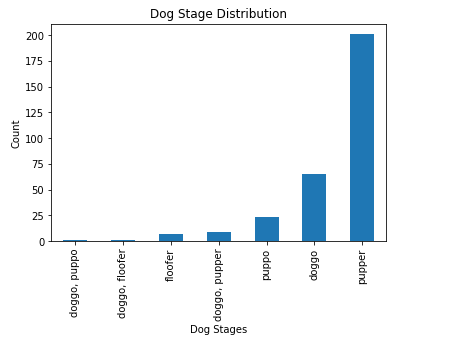

- From the graph above, we can see that *Pupper* is the most tweeted about dog stage. There are about 200 tweets with the dog stage followed by *doggo*
1. **Which dog stage is the most popular based on retweets and favourite count ?**

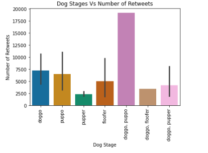

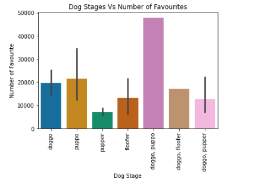

- Of the tweets with dog stages, ''doggo,puppo' had the most retweets and favourite counts despite having just one tweet with the doggo,puppo stage. This shows that this dog stage is liked by most people.
1. **Whats is the correlation between Retweet count and Favourite count ?**

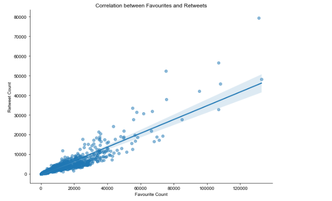

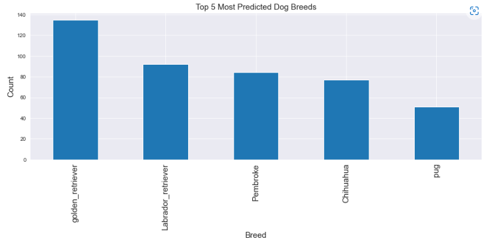

- The two most predicted dog types are Golden Retrievers and Labrator Retrievers. These two are usually the some of the most common dog breeds.
- Other dog breeds in the top 5 include Pembrokes, Chihuahuas and Pugs.

## Conclusion

- The dog stage *'pupper'* is the most popular based on number of tweets sent out.
- *'doggo,puppo'* stage had the most retweets and favourite counts despite having just one tweet with that dog stage.
- Analysis showed that there is a strong linear correlation between retweet count and favourite count. The regression coefficient is 0.787. This is what is expected because users usually favourite tweets that they retweet.
- Golden retriever, Labrador Retriever, Pembroke, Chihuahua and Pugs are the top 5 most common dog breeds predicted in the dataset.

## Areas of Further Research

- The rating columns for can be analysed for more insight.
- Only the 1st prediction column was used, all 3 columns may be used to determine the overall probability or popularity of dog breeds and how accurate predictions are in each tweet.